# Dissertation Analysis: Correlations - Collection Rate - Team Orientation

Jamiahus Walton

2019-06-29

# Motivation

The motivation behind this analysis is to discover different correlations between participants actual performance and self-reported performance. Significance was found in previous analysis regarding a sinificant difference in correct collection rate at the individual level and the goal of this analysis is to attempt to understand why there was significance.

**Note:** In TLX, a value of 0 for the performance channel is considered perfect and 100 is considered faile. This is because if you felt the you’re performance was perfect, then that would mean your task load was lower. For this analysis, performance was reverse coded so that 0 is failure and 100 is perfect.

**Note:** A lower collection rate value indicates a high performaing team. Units for the dependent variable are Sec per Item.

# Is there correlation between a actual performance (i.e., Collection Rate) and self-reported performance (i.e, Performance (reverse) from TLX)?

## Collection Rate - Collection_rate_correct_item_ind

### Plots and Stats

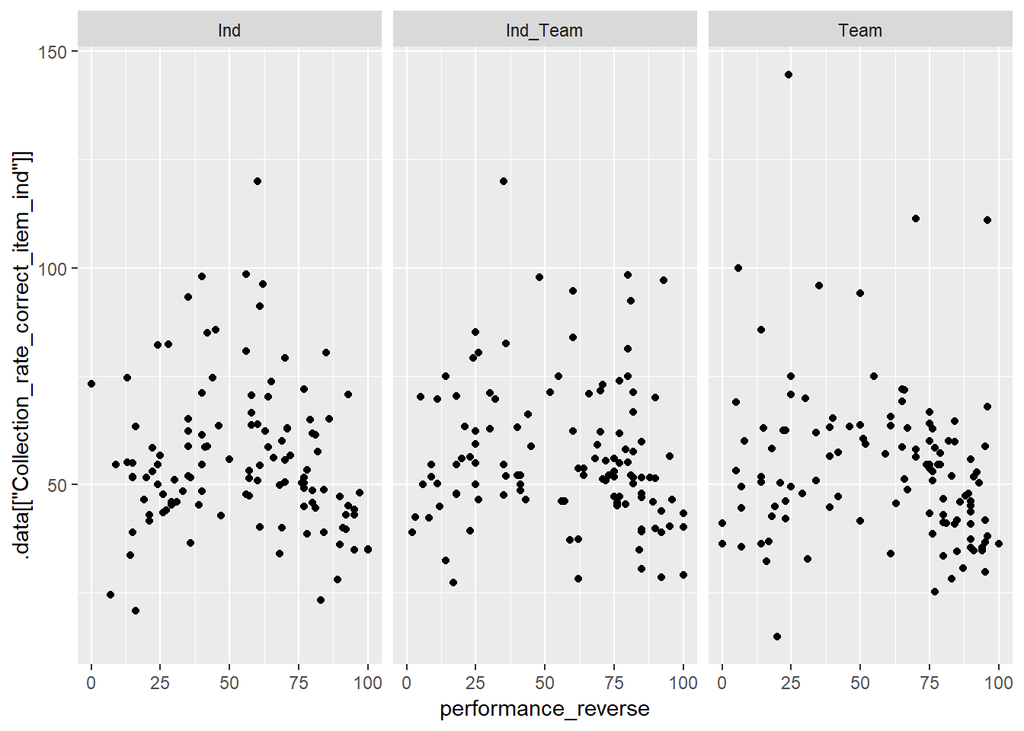

```r
# dependent<- "timeRemaining_ind"

plot_data_ind <- ind_data %>%
  select(Performance,
         params$dependent_response_ind,
         Target) %>%
  mutate(performance_reverse = 100 - Performance)

ggplot(data = plot_data_ind, aes(x = performance_reverse, y = .data[[params$dependent_response_ind]])) +
  geom_point() +
  facet_grid( . ~ Target)
```

No obious patterns. No obvious violation of monotonic relationship.

```r
# dependent<- "timeRemaining_ind"


for (my_target in c("Ind", "Team", "Ind_Team")) {

  plot_data_ind <- ind_data %>%
  select(Performance,
         params$dependent_response_ind,
         SessionOrder,
         Dominate.Strategy,
         My_Performance,
         Target,
         Player_ID) %>%
  mutate(performance_reverse = 100 - Performance) %>%
  filter(Target == my_target)

  N_paris<- length(plot_data_ind[[params$dependent_response_ind]])

  print(paste("Correltation: Condition =", my_target))
  print(paste("Pairs:", N_paris, ", Degree of Freedom:", N_paris-2))

  print(cor.test(y = plot_data_ind[[params$dependent_response_ind]], x = plot_data_ind[["performance_reverse"]], method = "spearman"))
  }
```

```
## [1] "Correltation: Condition = Ind"
## [1] "Pairs: 117 , Degree of Freedom: 115"
```

```
##
##  Spearman's rank correlation rho
##
## data:  plot_data_ind[["performance_reverse"]] and plot_data_ind[[params$dependent_response_ind]]
## S = 306610, p-value = 0.1096
## alternative hypothesis: true rho is not equal to 0
## sample estimates:
##        rho
## -0.1486996
##
## [1] "Correltation: Condition = Team"
## [1] "Pairs: 117 , Degree of Freedom: 115"
```

```
##
##  Spearman's rank correlation rho
##
## data:  plot_data_ind[["performance_reverse"]] and plot_data_ind[[params$dependent_response_ind]]
## S = 328220, p-value = 0.01274
## alternative hypothesis: true rho is not equal to 0
## sample estimates:
##        rho
## -0.2296683
##
## [1] "Correltation: Condition = Ind_Team"
## [1] "Pairs: 117 , Degree of Freedom: 115"
```

```
##
##  Spearman's rank correlation rho
##
## data:  plot_data_ind[["performance_reverse"]] and plot_data_ind[[params$dependent_response_ind]]
## S = 313920, p-value = 0.05751
## alternative hypothesis: true rho is not equal to 0
## sample estimates:
##        rho
## -0.1761178
```

When grouping paired responses for correct collection rate and performance (reverse) by Target, the results show a **significant** negative correltation for the Team condition. Indicating correct self perception of performance. Results also show a **marginally significant** negative correlation in the Ind_Team condition.

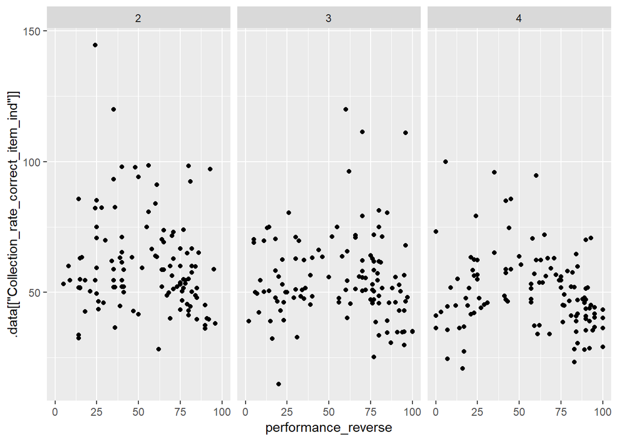

```r
# dependent<- "timeRemaining_ind"

plot_data_ind <- ind_data %>%
  select(Performance,
         params$dependent_response_ind,
         SessionOrder)%>%
  mutate(performance_reverse = 100 - Performance)

ggplot(data = plot_data_ind, aes(x = performance_reverse, y = .data[[params$dependent_response_ind]])) +
  geom_point() +
  facet_grid( . ~ SessionOrder)
```

No obvious violation of monotonic relationship.

```r
for (my_session in c(2:4)) {

  plot_data_ind <- ind_data %>%
  select(Performance,
         params$dependent_response_ind,
         SessionOrder) %>%
  mutate(performance_reverse = 100 - Performance) %>%
  filter(SessionOrder == my_session)

  N_paris<- length(plot_data_ind[[params$dependent_response_ind]])

  print(paste("Correltation: Session =", my_session))
  print(paste("Pairs:", N_paris, ", Degree of Freedom:", N_paris-2))

  print(cor.test(y = plot_data_ind[[params$dependent_response_ind]], x = plot_data_ind[["performance_reverse"]], method = "spearman"))
  }
```

```
## [1] "Correltation: Session = 2"
## [1] "Pairs: 117 , Degree of Freedom: 115"
```

```
##
##  Spearman's rank correlation rho
##
## data:  plot_data_ind[["performance_reverse"]] and plot_data_ind[[params$dependent_response_ind]]
## S = 310170, p-value = 0.08085
## alternative hypothesis: true rho is not equal to 0
## sample estimates:
##        rho
## -0.1620681
##
## [1] "Correltation: Session = 3"
## [1] "Pairs: 117 , Degree of Freedom: 115"
```

```
##
##  Spearman's rank correlation rho
##
## data:  plot_data_ind[["performance_reverse"]] and plot_data_ind[[params$dependent_response_ind]]
## S = 300950, p-value = 0.1706
## alternative hypothesis: true rho is not equal to 0
## sample estimates:
##       rho
## -0.127522
##
## [1] "Correltation: Session = 4"
## [1] "Pairs: 117 , Degree of Freedom: 115"
```

```
##
##  Spearman's rank correlation rho
##
## data:  plot_data_ind[["performance_reverse"]] and plot_data_ind[[params$dependent_response_ind]]
## S = 330700, p-value = 0.009469
## alternative hypothesis: true rho is not equal to 0
## sample estimates:
##        rho
## -0.2389561
```

When grouping paired responses for correct collection rate and performance (reverse) by session order, the results show a **significant** negative correlation for session 4. Indicating a correct perception of performance. The results also showed a **marginally significant** negative correlation in session 2.

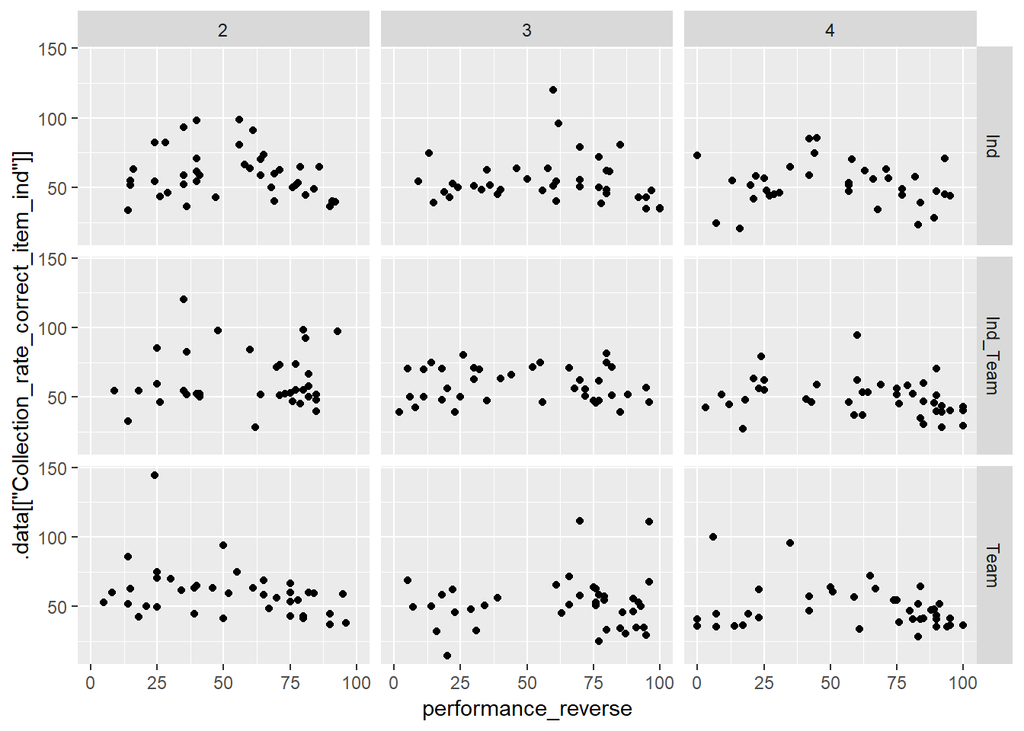

```r
# dependent<- "timeRemaining_ind"

plot_data_ind <- ind_data %>%
  select(Performance,
         params$dependent_response_ind,
         Target,
         SessionOrder)%>%
  mutate(performance_reverse = 100 - Performance)

ggplot(data = plot_data_ind, aes(x = performance_reverse, y = .data[[params$dependent_response_ind]])) +
  geom_point() +
  facet_grid( Target ~ SessionOrder)
```

No obvious violation of monotonic relationship.

```r
for (my_session in c(2:4)) {
  for (my_target in c("Ind", "Team", "Ind_Team")) {
    plot_data_ind <- ind_data %>%
      select(Performance,
             params$dependent_response_ind,
             SessionOrder,
             Target) %>%
      mutate(performance_reverse = 100 - Performance) %>%
      filter(Target == my_target, SessionOrder == my_session)

    N_paris<- length(plot_data_ind[[params$dependent_response_ind]])

  test<- cor.test(y = plot_data_ind[[params$dependent_response_ind]], x = plot_data_ind[["performance_reverse"]], method = "spearman")

  if(test$p.value < 0.1){
    print(paste("Correltation: Condition =", my_target,",", "Session =", my_session))
    print(paste("Pairs:", N_paris, ", Degree of Freedom:", N_paris-2))
  }
  print(test$p.value)
  }
}
```

```
## [1] 0.3285949
```

```
## [1] "Correltation: Condition = Team , Session = 2"
## [1] "Pairs: 39 , Degree of Freedom: 37"
## [1] 0.02625088
```

```
## [1] 0.9127084
```

```
## [1] 0.2099248
```

```
## [1] 0.6950705
```

```
## [1] 0.9624301
```

```
## [1] 0.5369975
```

```
## [1] 0.2555123
```

```
## [1] "Correltation: Condition = Ind_Team , Session = 4"
## [1] "Pairs: 42 , Degree of Freedom: 40"
## [1] 0.01963512
```

There was a **significant** correltation in the following condition and session combinations: Condition = Team , Session = 2 Condition = Ind_Team , Session = 4

```r
my_target<- "Team"
my_session<- 2

plot_data_ind <- ind_data %>%
      select(Performance,
             params$dependent_response_ind,
             SessionOrder,
             Target) %>%
      mutate(performance_reverse = 100 - Performance) %>%
      filter(Target == my_target, SessionOrder == my_session)

N_paris<- length(plot_data_ind[[params$dependent_response_ind]])

print(paste("Correltation: Condition =", my_target,",", "Session =", my_session))
```

```
## [1] "Correltation: Condition = Team , Session = 2"
```

```r
print(paste("Pairs:", N_paris, ", Degree of Freedom:", N_paris-2))
```

```
## [1] "Pairs: 39 , Degree of Freedom: 37"
```

```r
test<- cor.test(y = plot_data_ind[[params$dependent_response_ind]], x = plot_data_ind[["performance_reverse"]], method = "spearman")
print(test)
```

```
##
##  Spearman's rank correlation rho
##
## data:  plot_data_ind[["performance_reverse"]] and plot_data_ind[[params$dependent_response_ind]]
## S = 13395, p-value = 0.02625
## alternative hypothesis: true rho is not equal to 0
## sample estimates:
##        rho
## -0.3557246
```

```r
#----

my_target<- "Ind_Team"
my_session<- 4

plot_data_ind <- ind_data %>%
      select(Performance,
             params$dependent_response_ind,
             SessionOrder,
             Target) %>%
      mutate(performance_reverse = 100 - Performance) %>%
      filter(Target == my_target, SessionOrder == my_session)

N_paris<- length(plot_data_ind[[params$dependent_response_ind]])

print(paste("Correltation: Condition =", my_target,",", "Session =", my_session))
```

```
## [1] "Correltation: Condition = Ind_Team , Session = 4"
```

```r
print(paste("Pairs:", N_paris, ", Degree of Freedom:", N_paris-2))
```

```
## [1] "Pairs: 42 , Degree of Freedom: 40"
```

```r
test<- cor.test(y = plot_data_ind[[params$dependent_response_ind]], x = plot_data_ind[["performance_reverse"]], method = "spearman")
print(test)
```

```
##
##  Spearman's rank correlation rho
##
## data:  plot_data_ind[["performance_reverse"]] and plot_data_ind[[params$dependent_response_ind]]
## S = 16769, p-value = 0.01964
## alternative hypothesis: true rho is not equal to 0
## sample estimates:
##       rho
## -0.358777
```

There was a **significant** correltation in the following condition and session combinations: Condition = Team , Session = 2 Condition = Ind_Team , Session = 4

When grouping paired responses for correct collection rate and performance (reverse) by target and session order, the results showed a **significant** negative correlation for participants in Team in session 2, and for pariticpants in Ind_Team in session 4, indicating a correct perception.

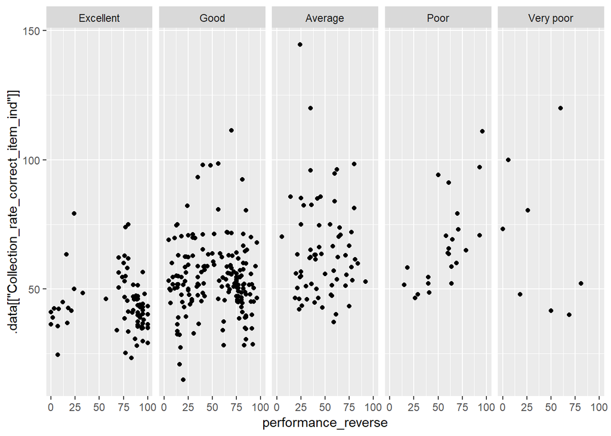

```r
# dependent <- "timeRemaining_ind"
plot_data_ind <- ind_data %>%
  select(Performance,
         params$dependent_response_ind,
         My_Performance) %>%
  mutate(performance_reverse = 100 - Performance) %>%
  mutate(My_Performance_f = factor(.data[["My_Performance"]], levels = c("Excellent", "Good", "Average", "Poor", "Very poor"))) # This mutate column was generated to order the facet groups.

ggplot(data = plot_data_ind, aes(x = performance_reverse, y = .data[[params$dependent_response_ind]])) +
  geom_point() +
  facet_grid(. ~ My_Performance_f)
```

No obvious violation of monotonic relationship.

```r
for (ind_rating in c("Excellent", "Good", "Average", "Poor", "Very poor")) {
  plot_data_ind <- ind_data %>%
        select(Performance,
               params$dependent_response_ind,
               My_Performance) %>%
        mutate(performance_reverse = 100 - Performance)%>%
        filter(My_Performance == ind_rating)

  N_paris<- length(plot_data_ind[[params$dependent_response_ind]])

  print(paste("Correltation: My_rating =", ind_rating))
  print(paste("Pairs:", N_paris, ", Degree of Freedom:", N_paris-2))

  test<- cor.test(y = plot_data_ind[[params$dependent_response_ind]], x = plot_data_ind[["performance_reverse"]], method = "spearman")

  print(test)
}
```

```
## [1] "Correltation: My_rating = Excellent"
## [1] "Pairs: 77 , Degree of Freedom: 75"
```

```
##
##  Spearman's rank correlation rho
##
## data:  plot_data_ind[["performance_reverse"]] and plot_data_ind[[params$dependent_response_ind]]
## S = 96619, p-value = 0.01755
## alternative hypothesis: true rho is not equal to 0
## sample estimates:
##        rho
## -0.2700277
##
## [1] "Correltation: My_rating = Good"
## [1] "Pairs: 175 , Degree of Freedom: 173"
```

```
##
##  Spearman's rank correlation rho
##
## data:  plot_data_ind[["performance_reverse"]] and plot_data_ind[[params$dependent_response_ind]]
## S = 967570, p-value = 0.2733
## alternative hypothesis: true rho is not equal to 0
## sample estimates:
##         rho
## -0.08325938
##
## [1] "Correltation: My_rating = Average"
## [1] "Pairs: 68 , Degree of Freedom: 66"
```

```
##
##  Spearman's rank correlation rho
##
## data:  plot_data_ind[["performance_reverse"]] and plot_data_ind[[params$dependent_response_ind]]
## S = 50407, p-value = 0.7588
## alternative hypothesis: true rho is not equal to 0
## sample estimates:
##        rho
## 0.03791813
##
## [1] "Correltation: My_rating = Poor"
## [1] "Pairs: 23 , Degree of Freedom: 21"
```

```
##
##  Spearman's rank correlation rho
##
## data:  plot_data_ind[["performance_reverse"]] and plot_data_ind[[params$dependent_response_ind]]
## S = 605.55, p-value = 0.0001956
## alternative hypothesis: true rho is not equal to 0
## sample estimates:
##       rho
## 0.7008177
##
## [1] "Correltation: My_rating = Very poor"
## [1] "Pairs: 8 , Degree of Freedom: 6"
##
##  Spearman's rank correlation rho
##
## data:  plot_data_ind[["performance_reverse"]] and plot_data_ind[[params$dependent_response_ind]]
## S = 110, p-value = 0.4618
## alternative hypothesis: true rho is not equal to 0
## sample estimates:
##        rho
## -0.3095238
```

When grouping paired responses for correct collection rate and performance (reverse) by self reported performance (e.g., poor vs. excellent), the results show a **significant** negative correlation for participants that rated their performance as Excellent, indicating a correct perception of performance. The results also showed a **singnificant** positive correlation for participants that rated their performance as Poor, indiciating an incorrect perception of performance.

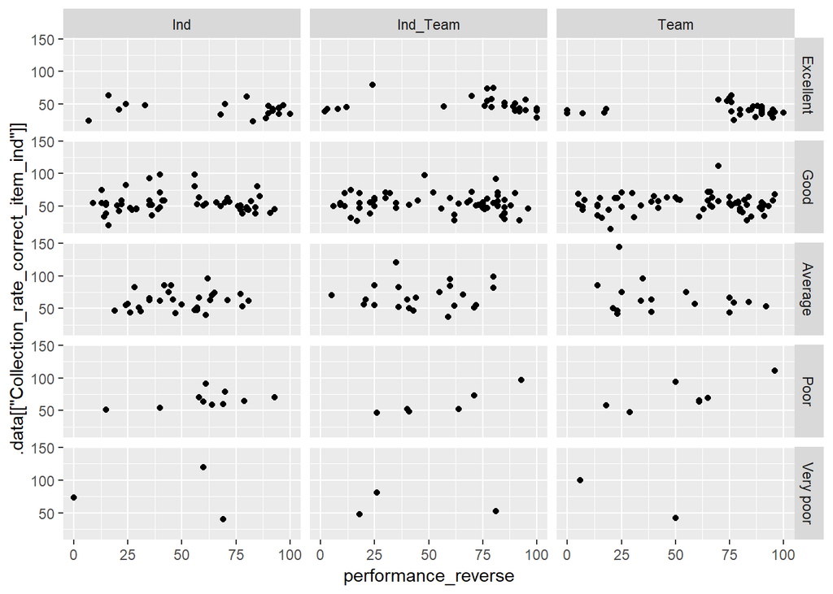

```r
# dependent<- "timeRemaining_ind"

plot_data_ind <- ind_data %>%
  select(Performance,
         params$dependent_response_ind,
         My_Performance,
         Target) %>%
  mutate(performance_reverse = 100 - Performance)%>%
  mutate(My_Performance_f = factor(.data[["My_Performance"]], levels = c("Excellent", "Good", "Average", "Poor", "Very poor"))) # This mutate column was generated to order the facet groups.

ggplot(data = plot_data_ind, aes(x = performance_reverse, y = .data[[params$dependent_response_ind]])) +
  geom_point() +
  facet_grid(My_Performance_f ~ Target)
```

No obvious violation of monotonic relationship.

```r
for (ind_rating in c("Excellent", "Good", "Average", "Poor", "Very poor")) {
  for (my_target in c("Ind", "Team", "Ind_Team")) {
    plot_data_ind <- ind_data %>%
        select(Performance,
               params$dependent_response_ind,
               My_Performance,
               Target) %>%
        mutate(performance_reverse = 100 - Performance)%>%
        filter(My_Performance == ind_rating, Target == my_target)

    N_paris<- length(plot_data_ind[[params$dependent_response_ind]])

    test<- cor.test(y = plot_data_ind[[params$dependent_response_ind]], x = plot_data_ind[["performance_reverse"]], method = "spearman")

    if(test$p.value < 0.1){
      print(paste("Correltation: Condition =", my_target, ", Rated_performance =", ind_rating))
      print(paste("Pairs:", N_paris, ", Degree of Freedom:", N_paris-2))
    }
    print(test$p.value)
  }
}
```

```
## [1] 0.4549406
```

```
## [1] 0.1232737
```

```
## [1] 0.1278067
```

```
## [1] 0.6924972
```

```
## [1] 0.7439568
```

```
## [1] 0.2297694
```

```
## [1] 0.2608433
```

```
## [1] 0.6219387
```

```
## [1] 0.8494385
## [1] 0.1042978
```

```
## [1] "Correltation: Condition = Team , Rated_performance = Poor"
## [1] "Pairs: 7 , Degree of Freedom: 5"
## [1] 0.0578585
## [1] "Correltation: Condition = Ind_Team , Rated_performance = Poor"
## [1] "Pairs: 6 , Degree of Freedom: 4"
## [1] 0.05833333
## [1] 1
## [1] 1
## [1] 1
```

The following show a **marginally significant** correlation: Condition = Team , Rated_performance = Poor Condition = Ind_Team , Rated_performance = Poor

```r
ind_rating<- "Poor"
my_target<- "Team"
plot_data_ind <- ind_data %>%
        select(Performance,
               params$dependent_response_ind,
               My_Performance,
               Target) %>%
        mutate(performance_reverse = 100 - Performance)%>%
        filter(My_Performance == ind_rating, Target == my_target)

N_paris<- length(plot_data_ind[[params$dependent_response_ind]])

    test<- cor.test(y = plot_data_ind[[params$dependent_response_ind]], x = plot_data_ind[["performance_reverse"]], method = "spearman")
    print(paste("Correltation: Condition =", my_target, ", Rated_performance =", ind_rating))
```

```
## [1] "Correltation: Condition = Team , Rated_performance = Poor"
```

```r
    print(paste("Pairs:", N_paris, ", Degree of Freedom:", N_paris-2))
```

```
## [1] "Pairs: 7 , Degree of Freedom: 5"
```

```r
    print(test)
```

```
##
##  Spearman's rank correlation rho
##
## data:  plot_data_ind[["performance_reverse"]] and plot_data_ind[[params$dependent_response_ind]]
## S = 14.629, p-value = 0.05786
## alternative hypothesis: true rho is not equal to 0
## sample estimates:
##       rho
## 0.7387687
```

```r
#----
ind_rating<- "Poor"
my_target<- "Ind_Team"
plot_data_ind <- ind_data %>%
        select(Performance,
               params$dependent_response_ind,
               My_Performance,
               Target) %>%
        mutate(performance_reverse = 100 - Performance)%>%
        filter(My_Performance == ind_rating, Target == my_target)

N_paris<- length(plot_data_ind[[params$dependent_response_ind]])

    test<- cor.test(y = plot_data_ind[[params$dependent_response_ind]], x = plot_data_ind[["performance_reverse"]], method = "spearman")

    print(paste("Correltation: Condition =", my_target, ", Rated_performance =", ind_rating))
```

```
## [1] "Correltation: Condition = Ind_Team , Rated_performance = Poor"
```

```r
    print(paste("Pairs:", N_paris, ", Degree of Freedom:", N_paris-2))
```

```
## [1] "Pairs: 6 , Degree of Freedom: 4"
```

```r
    print(test)
```

```
##
##  Spearman's rank correlation rho
##
## data:  plot_data_ind[["performance_reverse"]] and plot_data_ind[[params$dependent_response_ind]]
## S = 6, p-value = 0.05833
## alternative hypothesis: true rho is not equal to 0
## sample estimates:
##       rho
## 0.8285714
```

The following show a **marginally significant** correlation: Condition = Team , Rated_performance = Poor Condition = Ind_Team , Rated_performance = Poor

**Note:** There are very few participants that rated their performance as poor in the Team and Ind_Team conditions

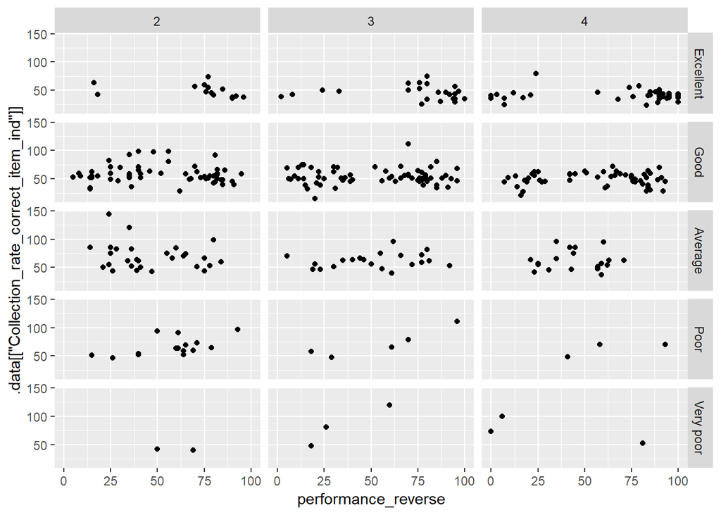

```r
# dependent<- "timeRemaining_ind"

plot_data_ind <- ind_data %>%
  select(Performance,
         params$dependent_response_ind,
         My_Performance,
         SessionOrder) %>%
  mutate(performance_reverse = 100 - Performance)%>%
  mutate(My_Performance_f = factor(.data[["My_Performance"]], levels = c("Excellent", "Good", "Average", "Poor", "Very poor"))) # This mutate column was generated to order the facet groups.

ggplot(data = plot_data_ind, aes(x = performance_reverse, y = .data[[params$dependent_response_ind]])) +
  geom_point() +
  facet_grid(My_Performance_f ~ SessionOrder)
```

No obvious violation of monotonic relationship.

```r
for (ind_rating in c("Excellent", "Good", "Average", "Poor", "Very poor")) {
  for (my_session in c(2:4)) {
    plot_data_ind <- ind_data %>%
        select(Performance,
               params$dependent_response_ind,
               My_Performance,
               SessionOrder) %>%
        mutate(performance_reverse = 100 - Performance)%>%
        filter(My_Performance == ind_rating, SessionOrder == my_session)

    N_paris<- length(plot_data_ind[[params$dependent_response_ind]])

    test<- cor.test(y = plot_data_ind[[params$dependent_response_ind]], x = plot_data_ind[["performance_reverse"]], method = "spearman")

    if(test$p.value < 0.1){
      print(paste("Correltation: Session =", my_session, ", Rated_performance =", ind_rating))
      print(paste("Pairs:", N_paris, ", Degree of Freedom:", N_paris-2))
    }
    print(test$p.value)
  }
}
```

```
## [1] "Correltation: Session = 2 , Rated_performance = Excellent"
## [1] "Pairs: 14 , Degree of Freedom: 12"
## [1] 0.00295921
```

```
## [1] 0.1148793
```

```
## [1] 0.7042128
```

```
## [1] 0.3566861
```

```
## [1] 0.6180004
```

```
## [1] 0.948355
```

```
## [1] 0.3312707
```

```
## [1] 0.3159883
```

```
## [1] 0.7914096
```

```
## [1] "Correltation: Session = 2 , Rated_performance = Poor"
## [1] "Pairs: 15 , Degree of Freedom: 13"
## [1] 0.01723925
## [1] "Correltation: Session = 3 , Rated_performance = Poor"
## [1] "Pairs: 5 , Degree of Freedom: 3"
## [1] 0.08333333
## [1] 0.3333333
## [1] 1
## [1] 0.3333333
## [1] 1
```

There was a **significant** correlations for the following: Session = 2 , Rated_performance = Excellent Session = 2 , Rated_performance = Poor

There was a **marginally significant** correlations for the following: Session = 3 , Rated_performance = Poor

```r
ind_rating<- "Excellent"
my_session<- 2

plot_data_ind <- ind_data %>%
        select(Performance,
               params$dependent_response_ind,
               My_Performance,
               SessionOrder) %>%
        mutate(performance_reverse = 100 - Performance)%>%
        filter(My_Performance == ind_rating, SessionOrder == my_session)

N_paris<- length(plot_data_ind[[params$dependent_response_ind]])

    test<- cor.test(y = plot_data_ind[[params$dependent_response_ind]], x = plot_data_ind[["performance_reverse"]], method = "spearman")
    if(test$p.value < 0.1){
      print(paste("Correltation: Session =", my_session, ", Rated_performance =", ind_rating))
      print(paste("Pairs:", N_paris, ", Degree of Freedom:", N_paris-2))
    }
```

```
## [1] "Correltation: Session = 2 , Rated_performance = Excellent"
## [1] "Pairs: 14 , Degree of Freedom: 12"
```

```r
    print(test)
```

```
##
##  Spearman's rank correlation rho
##
## data:  plot_data_ind[["performance_reverse"]] and plot_data_ind[[params$dependent_response_ind]]
## S = 787.73, p-value = 0.002959
## alternative hypothesis: true rho is not equal to 0
## sample estimates:
##        rho
## -0.7312793
```

```r
#----
ind_rating<- "Poor"
my_session<- 2

plot_data_ind <- ind_data %>%
        select(Performance,
               params$dependent_response_ind,
               My_Performance,
               SessionOrder) %>%
        mutate(performance_reverse = 100 - Performance)%>%
        filter(My_Performance == ind_rating, SessionOrder == my_session)

N_paris<- length(plot_data_ind[[params$dependent_response_ind]])

    test<- cor.test(y = plot_data_ind[[params$dependent_response_ind]], x = plot_data_ind[["performance_reverse"]], method = "spearman")
    if(test$p.value < 0.1){
      print(paste("Correltation: Session =", my_session, ", Rated_performance =", ind_rating))
      print(paste("Pairs:", N_paris, ", Degree of Freedom:", N_paris-2))
    }
```

```
## [1] "Correltation: Session = 2 , Rated_performance = Poor"
## [1] "Pairs: 15 , Degree of Freedom: 13"
```

```r
    print(test)
```

```
##
##  Spearman's rank correlation rho
##
## data:  plot_data_ind[["performance_reverse"]] and plot_data_ind[[params$dependent_response_ind]]
## S = 222.09, p-value = 0.01724
## alternative hypothesis: true rho is not equal to 0
## sample estimates:
##       rho
## 0.6034041
```

When grouping paired responses for correct collection rate and performance (reverse) by session order and self reported performance (e.g., poor vs. excellent), the results showed a **significant** negative correlations for participants in session 2 that rated themsleves as Excellent, indicating a correct perception. The results showed a **significant** positive correlation for participants in session 2 that rated themselves as Poor, indicating an incorrect perception of performance.

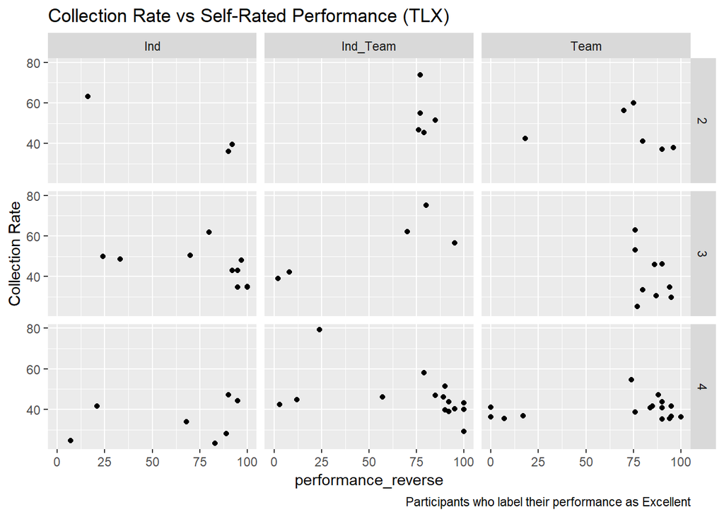

```r
# dependent<- "timeRemaining_ind"
y_lab_indep <- params$dependent_response_name_WithSpace

post_session_labled_performance<- "Excellent"
plot_data_ind <- ind_data %>%
  select(Performance,
         params$dependent_response_ind,
         My_Performance,
         SessionOrder,
         Target) %>%
  mutate(performance_reverse = 100 - Performance)%>%
  filter(My_Performance == post_session_labled_performance)

ggplot(data = plot_data_ind, aes(x = performance_reverse, y = .data[[params$dependent_response_ind]])) +
  geom_point() +
  labs(title = paste(y_lab_indep, "vs Self-Rated Performance (TLX)"), caption = paste("Participants who label their performance as", post_session_labled_performance) , y = y_lab_indep) +
  facet_grid(SessionOrder ~ Target)
```

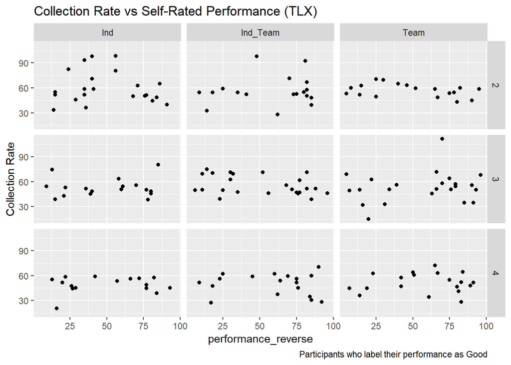

```r
post_session_labled_performance<- "Good"
plot_data_ind <- ind_data %>%
  select(Performance,
         params$dependent_response_ind,
         My_Performance,
         SessionOrder,
         Target) %>%
  mutate(performance_reverse = 100 - Performance)%>%
  filter(My_Performance == post_session_labled_performance)

ggplot(data = plot_data_ind, aes(x = performance_reverse, y = .data[[params$dependent_response_ind]])) +
  geom_point() +
  labs(title = paste(y_lab_indep, "vs Self-Rated Performance (TLX)"), caption = paste("Participants who label their performance as", post_session_labled_performance) , y = y_lab_indep) +
  facet_grid(SessionOrder ~ Target)
```

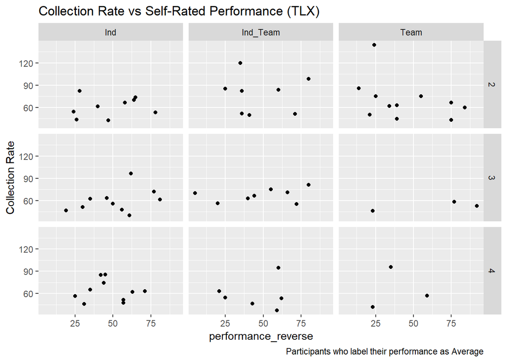

```r
post_session_labled_performance<- "Average"
plot_data_ind <- ind_data %>%
  select(Performance,
         params$dependent_response_ind,
         My_Performance,
         SessionOrder,
         Target) %>%
  mutate(performance_reverse = 100 - Performance)%>%
  filter(My_Performance == post_session_labled_performance)

ggplot(data = plot_data_ind, aes(x = performance_reverse, y = .data[[params$dependent_response_ind]])) +
  geom_point() +
  labs(title = paste(y_lab_indep, "vs Self-Rated Performance (TLX)"), caption = paste("Participants who label their performance as", post_session_labled_performance) , y = y_lab_indep) +
  facet_grid(SessionOrder ~ Target)
```

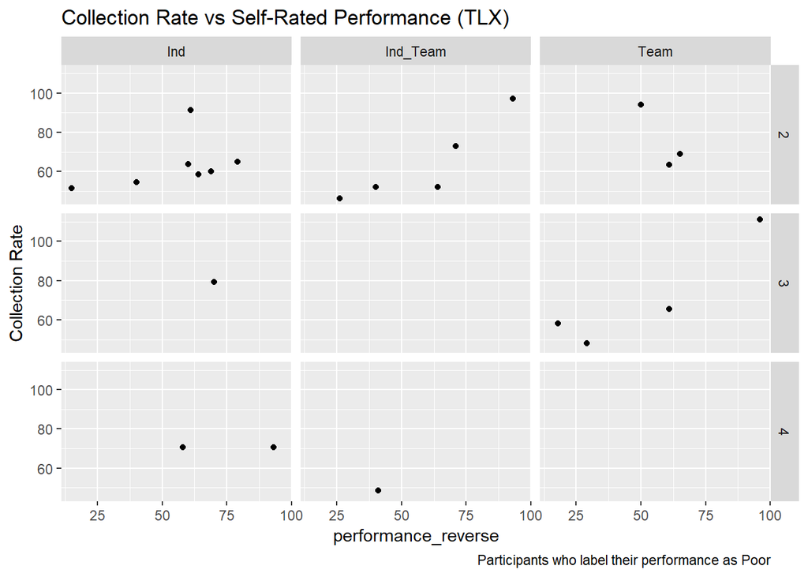

```r
post_session_labled_performance<- "Poor"
plot_data_ind <- ind_data %>%
  select(Performance,
         params$dependent_response_ind,
         My_Performance,
         SessionOrder,
         Target) %>%
  mutate(performance_reverse = 100 - Performance)%>%
  filter(My_Performance == post_session_labled_performance)

ggplot(data = plot_data_ind, aes(x = performance_reverse, y = .data[[params$dependent_response_ind]])) +
  geom_point() +
  labs(title = paste(y_lab_indep, "vs Self-Rated Performance (TLX)"), caption = paste("Participants who label their performance as", post_session_labled_performance) , y = y_lab_indep) +
  facet_grid(SessionOrder ~ Target)
```

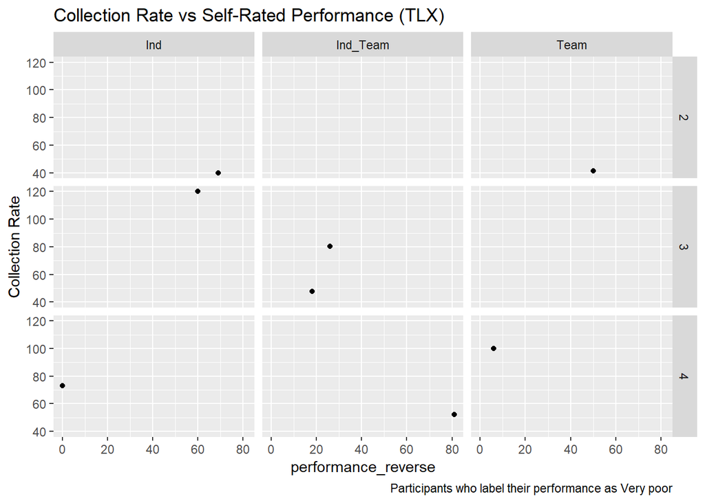

```r
post_session_labled_performance<- "Very poor"
plot_data_ind <- ind_data %>%
  select(Performance,
         params$dependent_response_ind,
         My_Performance,
         SessionOrder,
         Target) %>%
  mutate(performance_reverse = 100 - Performance)%>%
  filter(My_Performance == post_session_labled_performance)

ggplot(data = plot_data_ind, aes(x = performance_reverse, y = .data[[params$dependent_response_ind]])) +
  geom_point() +
  labs(title = paste(y_lab_indep, "vs Self-Rated Performance (TLX)"), caption = paste("Participants who label their performance as", post_session_labled_performance) , y = y_lab_indep) +
  facet_grid(SessionOrder ~ Target)
```

No obvious violation of monotonic relationship.

```r
for (ind_rating in c("Excellent", "Good", "Average", "Poor", "Very poor")) {
  for (my_target in c("Ind", "Team", "Ind_Team")) {
    for (my_session in c(2:4)) {
      plot_data_ind <- ind_data %>%
        select(Performance,
               params$dependent_response_ind,
               SessionOrder,
               Dominate.Strategy,
               My_Performance,
               Target,
               Player_ID) %>%
        mutate(performance_reverse = 100 - Performance)%>%
        filter(Target == my_target, My_Performance == ind_rating, SessionOrder == my_session)

      N_paris<- length(plot_data_ind[[params$dependent_response_ind]])

      if(length(plot_data_ind[[params$dependent_response_ind]]) < 3){
        message<- paste("There is less than 3 data point for the Condition =", my_target, ", Session =", my_session, ", Rated individual Performance =", ind_rating)
        print(message)
      } else {
        cor_test_results<- cor.test(x = plot_data_ind[["performance_reverse"]], y = plot_data_ind[[params$dependent_response_ind]], method = "spearman")

        if(cor_test_results$p.value < 0.1){
          print(paste("Correltation: Condition =", my_target, ", Session =", my_session, ", Rated individual Performance =", ind_rating))
          print(paste("Pairs:", N_paris, ", Degree of Freedom:", N_paris-2))
        }
        print(cor_test_results$p.value)
      }
    }
  }
}
```

```
## [1] 1
```

```
## [1] "Correltation: Condition = Ind , Session = 3 , Rated individual Performance = Excellent"
## [1] "Pairs: 10 , Degree of Freedom: 8"
## [1] 0.0189839
## [1] 0.2357143
## [1] 0.1361111
```

```
## [1] 0.2519567
```

```
## [1] 0.8449325
```

```
## [1] 0.8048288
## [1] 0.2333333
```

```
## [1] "Correltation: Condition = Ind_Team , Session = 4 , Rated individual Performance = Excellent"
## [1] "Pairs: 16 , Degree of Freedom: 14"
## [1] 0.009910711
```

```
## [1] 0.6757731
```

```
## [1] 0.9627448
```

```
## [1] 0.7948914
```

```
## [1] 0.26077
```

```
## [1] 0.4611073
```

```
## [1] 0.696747
```

```
## [1] 0.8320834
```

```
## [1] 0.1688632
```

```
## [1] 0.9125179
## [1] 0.6436398
## [1] 0.2789652
```

```
## [1] 0.9203185
```

```
## [1] 0.1579999
## [1] 1
## [1] 1
```

```
## [1] 0.5479426
## [1] 0.427877
## [1] 0.8027778
## [1] 0.1666667
## [1] "There is less than 3 data point for the Condition = Ind , Session = 3 , Rated individual Performance = Poor"
## [1] "There is less than 3 data point for the Condition = Ind , Session = 4 , Rated individual Performance = Poor"
## [1] 1
## [1] 0.3333333
## [1] "There is less than 3 data point for the Condition = Team , Session = 4 , Rated individual Performance = Poor"
## [1] "Correltation: Condition = Ind_Team , Session = 2 , Rated individual Performance = Poor"
## [1] "Pairs: 5 , Degree of Freedom: 3"
## [1] 0.08333333
## [1] "There is less than 3 data point for the Condition = Ind_Team , Session = 3 , Rated individual Performance = Poor"
## [1] "There is less than 3 data point for the Condition = Ind_Team , Session = 4 , Rated individual Performance = Poor"
## [1] "There is less than 3 data point for the Condition = Ind , Session = 2 , Rated individual Performance = Very poor"
## [1] "There is less than 3 data point for the Condition = Ind , Session = 3 , Rated individual Performance = Very poor"
## [1] "There is less than 3 data point for the Condition = Ind , Session = 4 , Rated individual Performance = Very poor"
## [1] "There is less than 3 data point for the Condition = Team , Session = 2 , Rated individual Performance = Very poor"
## [1] "There is less than 3 data point for the Condition = Team , Session = 3 , Rated individual Performance = Very poor"
## [1] "There is less than 3 data point for the Condition = Team , Session = 4 , Rated individual Performance = Very poor"
## [1] "There is less than 3 data point for the Condition = Ind_Team , Session = 2 , Rated individual Performance = Very poor"
## [1] "There is less than 3 data point for the Condition = Ind_Team , Session = 3 , Rated individual Performance = Very poor"
## [1] "There is less than 3 data point for the Condition = Ind_Team , Session = 4 , Rated individual Performance = Very poor"
```

Condition = Ind , Session = 3 , Rated individual Performance = Excellent, **significant** Condition = Ind_Team , Session = 4 , Rated individual Performance = Excellent, **significant** Condition = Ind_Team , Session = 2 , Rated individual Performance = Poor, **marginally significant**

```r
# dependent<- "timeRemaining_ind"
current_target<- "Ind"
current_my_performance<-  "Excellent"
current_Session<- 3

plot_data_ind <- ind_data %>%
  select(Performance,
         params$dependent_response_ind,
         SessionOrder,
         Dominate.Strategy,
         My_Performance,
         Target,
         Player_ID) %>%
  mutate(performance_reverse = 100 - Performance) %>%
  filter(Target == current_target, My_Performance == current_my_performance, SessionOrder == current_Session)

N_paris<- length(plot_data_ind[[params$dependent_response_ind]])

print(paste("Correltation: Condition =", current_target, ", Session =", current_Session, ", Rated individual Performance =", current_my_performance))
```

```
## [1] "Correltation: Condition = Ind , Session = 3 , Rated individual Performance = Excellent"
```

```r
print(paste("Pairs:", N_paris, ", Degree of Freedom:", N_paris-2))
```

```
## [1] "Pairs: 10 , Degree of Freedom: 8"
```

```r
cor.test(y = plot_data_ind[[params$dependent_response_ind]], x = plot_data_ind[["performance_reverse"]], method = "spearman")
```

```
##
##  Spearman's rank correlation rho
##
## data:  plot_data_ind[["performance_reverse"]] and plot_data_ind[[params$dependent_response_ind]]
## S = 283.72, p-value = 0.01898
## alternative hypothesis: true rho is not equal to 0
## sample estimates:
##        rho
## -0.7195256
```

```r
#----

current_target<- "Ind_Team"
current_my_performance<-  "Excellent"
current_Session<- 4

plot_data_ind <- ind_data %>%
  select(Performance,
         params$dependent_response_ind,
         SessionOrder,
         Dominate.Strategy,
         My_Performance,
         Target,
         Player_ID) %>%
  mutate(performance_reverse = 100 - Performance) %>%
  filter(Target == current_target, My_Performance == current_my_performance, SessionOrder == current_Session)

N_paris<- length(plot_data_ind[[params$dependent_response_ind]])

print(paste("Correltation: Condition =", current_target, ", Session =", current_Session, ", Rated individual Performance =", current_my_performance))
```

```
## [1] "Correltation: Condition = Ind_Team , Session = 4 , Rated individual Performance = Excellent"
```

```r
print(paste("Pairs:", N_paris, ", Degree of Freedom:", N_paris-2))
```

```
## [1] "Pairs: 16 , Degree of Freedom: 14"
```

```r
cor.test(y = plot_data_ind[[params$dependent_response_ind]], x = plot_data_ind[["performance_reverse"]], method = "spearman")
```

```
##
##  Spearman's rank correlation rho
##
## data:  plot_data_ind[["performance_reverse"]] and plot_data_ind[[params$dependent_response_ind]]
## S = 1103.8, p-value = 0.009911
## alternative hypothesis: true rho is not equal to 0
## sample estimates:
##        rho
## -0.6231701
```

When grouping paired responses for correct collection rate and performance (reverse) by Target, session order, and self reported performance (e.g., poor vs. excellent), the results show a **significant** negative correlation for participants in Individual conditio in session 3 and labeled their performance as excellent, indicating a correct self-perception of performance. The results show a **significant** negative correlation for participants in Ind_Team condition in session 4 and labaled their performance as Excellent.

## Summary

“When grouping paired responses for correct collection rate and performance (reverse) by Target, the results show a **significant** negative correltation for the Team condition. Indicating correct self perception of performance. Results also show a **marginally significant** negative correlation in the Ind_Team condition.”

“When grouping paired responses for correct collection rate and performance (reverse) by session order, the results show a **significant** negative correlation for session 4. Indicating a correct perception of performance. The results also showed a **marginally significant** negative correlation in session 2.”

“When grouping paired responses for correct collection rate and performance (reverse) by target and session order, the results showed a **significant** negative correlation for participants in Team in session 2, and for pariticpants in Ind_Team in session 4, indicating a correct perception.”

“When grouping paired responses for correct collection rate and performance (reverse) by self reported performance (e.g., poor vs. excellent), the results show a **significant** negative correlation for participants that rated their performance as Excellent, indicating a correct perception of performance. The results also showed a **singnificant** positive correlation for participants that rated their performance as Poor, indiciating an incorrect perception of performance.”

“When grouping paired responses for correct collection rate and performance (reverse) by session order and self reported performance (e.g., poor vs. excellent), the results showed a **significant** negative correlations for participants in session 2 that rated themsleves as Excellent, indicating a correct perception. The results showed a **significant** positive correlation for participants in session 2 that rated themselves as Poor, indicating an incorrect perception of performance.”

“When grouping paired responses for correct collection rate and performance (reverse) by Target, session order, and self reported performance (e.g., poor vs. excellent), the results show a **significant** negative correlation for participants in Individual conditio in session 3 and labeled their performance as excellent, indicating a correct self-perception of performance. The results show a **significant** negative correlation for participants in Ind_Team condition in session 4 and labaled their performance as Excellent.”